# Stars 2

Walter Humberto Subiza Pina

12/5/2020

## Manipulación de objetos stars raster y vectoriales

Comenzamos cargando nuevamente la imagen de exemplo de la biblioteca **stars**. El archivo es una imagem Landsat 7 ETM, con 6 bandas, azul, verde, rojo (BGR) y 3 más de infrarrojo, en formato Geotiff.

```r
library(stars)
```

### Leyendo el raster

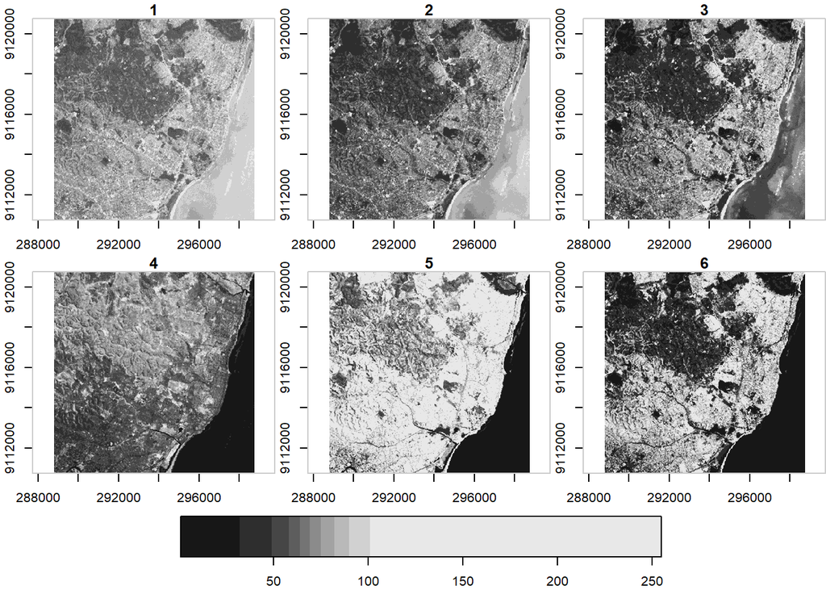

```r
tif = system.file("tif/L7_ETMs.tif", package = "stars")# creacion del camino del archivo como objeto texto

img = read_stars(tif) # lectura del archivo

plot(img, axes = T) # visualizer las 6 bandas
```

Es un objeto de 3 dimensiones, *x*, *y*, *band* en formato de lista; Inspeccionando o objeto *img* en la ventana de ambiente de *RStudio*, vemos un vector numérico con el tamaño de cada dimensión [1:349, 1:352, 1:6] y los valores a continuación.

### Conversión de dimensión en atributos y atributos en dimensión

El objeto leído tiene en su tercera dimensión *band* una lista con las bandas 1 a 6. Es posible pasar las bandas para atributos y eliminar la dimensión correspondiente.

De esta forma el nuevo objeto que crearemos tendrá solamente las dimensiones espaciales de *x* e *y* y 6 nuevos atributos. La función que será usada es *split()*, que divide los datos indicados en el primer argumento, de acuerdo a grupos definidos por el segundo argumento colocado.

```r
# separación de la imagen por la dimensión bandas
(img.sep = split(img, "band"))
```

```
## stars object with 2 dimensions and 6 attributes
## attribute(s):
##       X1               X2               X3               X4
##  Min.   : 47.00   Min.   : 32.00   Min.   : 21.00   Min.   :  9.00
##  1st Qu.: 67.00   1st Qu.: 55.00   1st Qu.: 49.00   1st Qu.: 52.00
##  Median : 78.00   Median : 66.00   Median : 63.00   Median : 63.00
##  Mean   : 79.15   Mean   : 67.57   Mean   : 64.36   Mean   : 59.24
##  3rd Qu.: 89.00   3rd Qu.: 79.00   3rd Qu.: 77.00   3rd Qu.: 75.00
##  Max.   :255.00   Max.   :255.00   Max.   :255.00   Max.   :255.00
##       X5               X6
##  Min.   :  1.00   Min.   :  1.00
##  1st Qu.: 63.00   1st Qu.: 32.00
##  Median : 89.00   Median : 60.00
##  Mean   : 83.18   Mean   : 59.98
##  3rd Qu.:112.00   3rd Qu.: 88.00
##  Max.   :255.00   Max.   :255.00
## dimension(s):
##   from  to  offset delta                       refsys point values
## x    1 349  288776  28.5 UTM Zone 25, Southern Hem... FALSE   NULL [x]
## y    1 352 9120761 -28.5 UTM Zone 25, Southern Hem... FALSE   NULL [y]
```

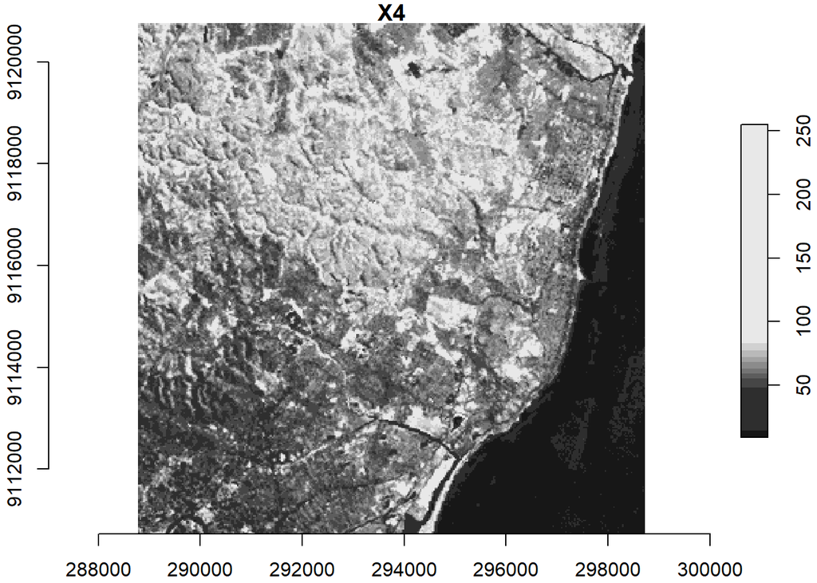

```r
# visualización del atributo X4, anterior banda 4
plot(img.sep["X4"], axes = T)
```

El objeto es del tipo “Large stars” con 2 dimensiones y 6 atributos de X1:X6, con los valores separados por atributo.

Hecer el camino contrario también es fácil, o sea tenemos um objeto con dos dimensiones y 6 atributos y queremos colocar los atributos en una única dimensión, la función *merge()* realiza la tarea.

Convertiendo todos los atributos en una única dimension.

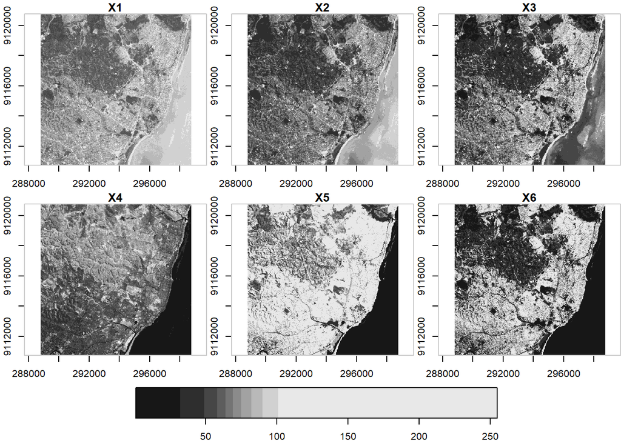

```r
img2 <-merge(img.sep)

plot(img2, axes = T)
```

Volvemos al formato del comienzo, pero en ese proceso se perdieron algunos nombres en la nueva dimension creada. Podemos restaurar los nombres iniciales o colocar nuevos como en el ejemplo siguiente

```r
img2 <- merge(img.sep) %>%
  setNames(names(img)) %>%
  st_set_dimensions(3,  # definiendo los nombres de las bandas en la dimensión 3
                    values = paste0("banda ", 1:6)) %>%
  st_set_dimensions(names = c("lon", "lat", "banda")) # nombres de las dimensiones

img2
```

```
## stars object with 3 dimensions and 1 attribute
## attribute(s):
##   L7_ETMs.tif
##  Min.   :  1.00
##  1st Qu.: 54.00
##  Median : 69.00
##  Mean   : 68.91
##  3rd Qu.: 86.00
##  Max.   :255.00
## dimension(s):
##       from  to  offset delta                       refsys point
## lon      1 349  288776  28.5 UTM Zone 25, Southern Hem... FALSE
## lat      1 352 9120761 -28.5 UTM Zone 25, Southern Hem... FALSE
## banda    1   6      NA    NA                           NA    NA
##                    values
## lon                  NULL [x]
## lat                  NULL [y]
## banda banda 1,...,banda 6
```

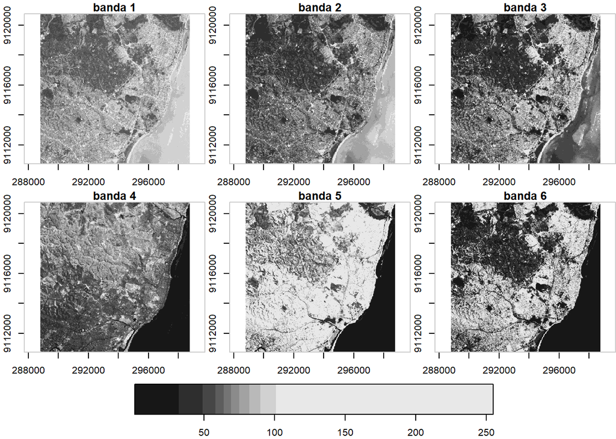

```r
plot(img2, axes = T)
```

### Extracción de valores usando objetos vectoriales

Cargamos en el ambiente el polígono del municipio de Olinda, usado en el documento anterior.

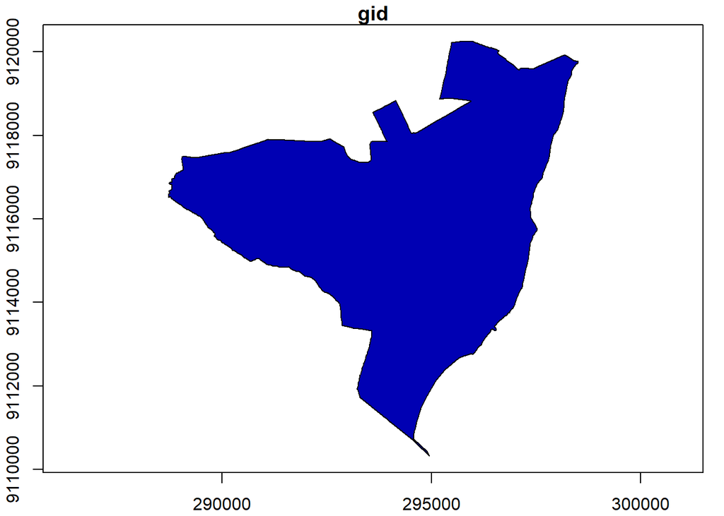

```r
olinda <- read_sf("C:/Users/Walter Pina/Documents/Github/spatial_stars/datos/olinda.shp") # lectura del archivo, el camino debe ser actualizado con los datos de la verdadera localización en su computador

plot(olinda["gid"], axes = T)
```

El paso a paso para extrair valores de la imagen usando el polígono es:

1. Verificar se ambos objetos están en el mismo sistema de referencia.

```r
st_crs(olinda)
```

```
## Coordinate Reference System:
##   User input: WGS 84 / UTM zone 25S
##   wkt:
## PROJCRS["WGS 84 / UTM zone 25S",
##     BASEGEOGCRS["WGS 84",
##         DATUM["World Geodetic System 1984",
##             ELLIPSOID["WGS 84",6378137,298.257223563,
##                 LENGTHUNIT["metre",1]]],
##         PRIMEM["Greenwich",0,
##             ANGLEUNIT["degree",0.0174532925199433]],
##         ID["EPSG",4326]],
##     CONVERSION["UTM zone 25S",
##         METHOD["Transverse Mercator",
##             ID["EPSG",9807]],
##         PARAMETER["Latitude of natural origin",0,
##             ANGLEUNIT["Degree",0.0174532925199433],
##             ID["EPSG",8801]],
##         PARAMETER["Longitude of natural origin",-33,
##             ANGLEUNIT["Degree",0.0174532925199433],
##             ID["EPSG",8802]],
##         PARAMETER["Scale factor at natural origin",0.9996,
##             SCALEUNIT["unity",1],
##             ID["EPSG",8805]],
##         PARAMETER["False easting",500000,
##             LENGTHUNIT["metre",1],
##             ID["EPSG",8806]],
##         PARAMETER["False northing",10000000,
##             LENGTHUNIT["metre",1],
##             ID["EPSG",8807]]],
##     CS[Cartesian,2],
##         AXIS["(E)",east,
##             ORDER[1],
##             LENGTHUNIT["metre",1]],
##         AXIS["(N)",north,
##             ORDER[2],
##             LENGTHUNIT["metre",1]],
##     ID["EPSG",32725]]
```

```r
st_crs(img)
```

```
## Coordinate Reference System:
##   User input: UTM Zone 25, Southern Hemisphere
##   wkt:
## BOUNDCRS[
##     SOURCECRS[
##         PROJCRS["UTM Zone 25, Southern Hemisphere",
##             BASEGEOGCRS["GRS 1980(IUGG, 1980)",
##                 DATUM["unknown",
##                     ELLIPSOID["GRS80",6378137,298.257222101,
##                         LENGTHUNIT["metre",1,
##                             ID["EPSG",9001]]]],
##                 PRIMEM["Greenwich",0,
##                     ANGLEUNIT["degree",0.0174532925199433,
##                         ID["EPSG",9122]]]],
##             CONVERSION["Transverse Mercator",
##                 METHOD["Transverse Mercator",
##                     ID["EPSG",9807]],
##                 PARAMETER["Latitude of natural origin",0,
##                     ANGLEUNIT["degree",0.0174532925199433],
##                     ID["EPSG",8801]],
##                 PARAMETER["Longitude of natural origin",-33,
##                     ANGLEUNIT["degree",0.0174532925199433],
##                     ID["EPSG",8802]],
##                 PARAMETER["Scale factor at natural origin",0.9996,
##                     SCALEUNIT["unity",1],
##                     ID["EPSG",8805]],
##                 PARAMETER["False easting",500000,
##                     LENGTHUNIT["metre",1],
##                     ID["EPSG",8806]],
##                 PARAMETER["False northing",10000000,
##                     LENGTHUNIT["metre",1],
##                     ID["EPSG",8807]]],
##             CS[Cartesian,2],
##                 AXIS["easting",east,
##                     ORDER[1],
##                     LENGTHUNIT["metre",1,
##                         ID["EPSG",9001]]],
##                 AXIS["northing",north,
##                     ORDER[2],
##                     LENGTHUNIT["metre",1,
```

[output cut: 22 more lines]

```
##             ID["EPSG",9606]],
##         PARAMETER["X-axis translation",0,
##             ID["EPSG",8605]],
##         PARAMETER["Y-axis translation",0,
##             ID["EPSG",8606]],
##         PARAMETER["Z-axis translation",0,
##             ID["EPSG",8607]],
##         PARAMETER["X-axis rotation",0,
##             ID["EPSG",8608]],
##         PARAMETER["Y-axis rotation",0,
##             ID["EPSG",8609]],
##         PARAMETER["Z-axis rotation",0,
##             ID["EPSG",8610]],
##         PARAMETER["Scale difference",1,
##             ID["EPSG",8611]]]]
```

De los resultados verificamos que están en diferentes sistemas, siendo que a pesar de los dos estar en sistema UTM y en la misma zona 25S, los elipsoides no coinciden, a saber:

| objeto | CRS | Elipsoide |
| --- | --- | --- |
| olinda | WGS 84 / UTM zone 25S | ELLIPSOID[“WGS 84”,6378137,298.257223563 |
| img | UTM Zone 25, Southern Hemisphere | ELLIPSOID[“GRS80”,6378137,298.257222101 |

2. La imagen y el poligono de corte estan en sistemas de referencia diferentes, deben ser compatibilizados. El procedimiento correcto es *transformar* las coordenadas de un objeto en el sistema de referencia del otro. Escogemos compatibilizar al sistema WGS84, pero podria ser al contrario.

```r
img <- st_transform(img, st_crs(olinda))
```

3. Estando los dos objetos con el mismo sistema de referencia, vamos cortar la imagen en las bandas 1 a 3 (BGR), usando el poligono del municipio. El corte será hecho con el uso del paréntesis recto, como vimos en el documento 1 de esta serie.

```r
img_corte1 <- img[olinda][, , , 1:3]
```

4. Visualizar la imagen cortada en la primera banda y el poligono de corte

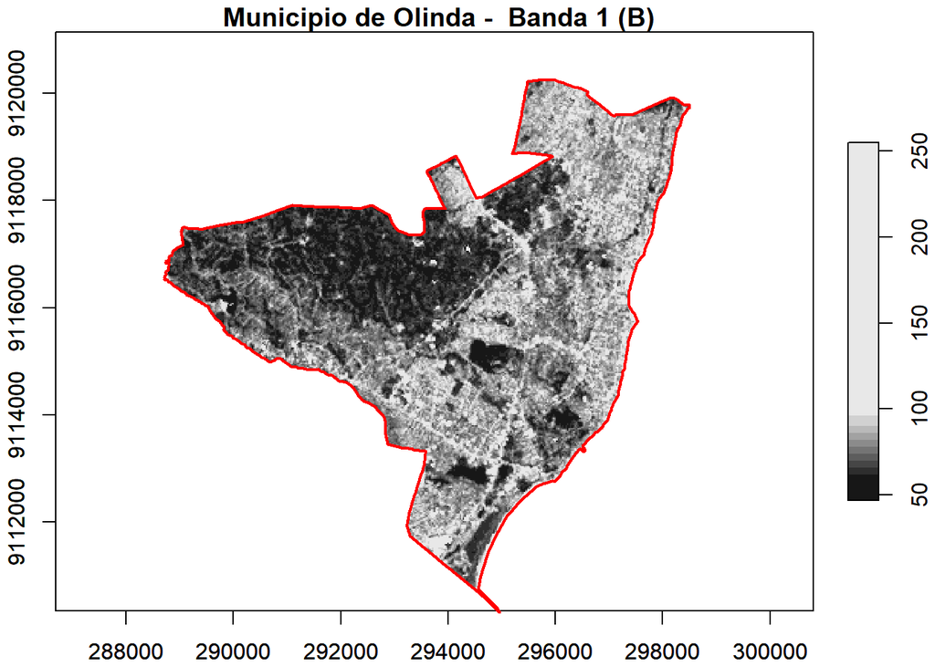

```r
plot(img_corte1[, , , 1],
     reset = FALSE,
     axes  = T,
     main  = " Municipio de Olinda -  Banda 1 (B)")

plot(olinda,
     col    = NA,
     border = 'red',
     add    = TRUE,
     lwd    = 2)
```

Y todas las bandas cortadas…

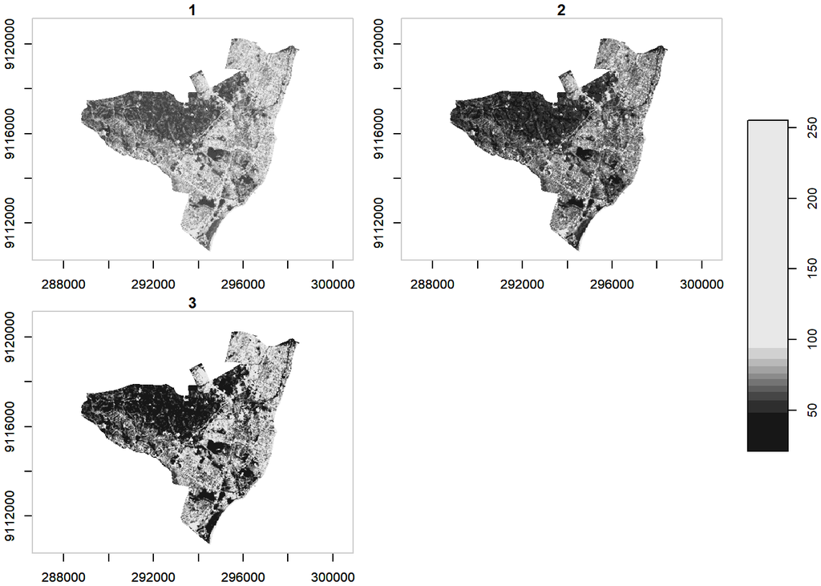

```r
plot(img_corte1, axes = T)
```

Otra forma de cortar (clip) uma imagen, es creando dentro del propio ambiente *R* un objeto vectorial de corte. Comenzaremos con el mas simple, que es un círculo creado alrededor de un punto determinado.

1. Creación de un buffer de 2 km con centro en el el punto (291500, 9117500), definición del sistema de referencia igual al de la imagen a cortar.
2. Corte de la imagen con el círculo de 2 km
3. Visualizacion

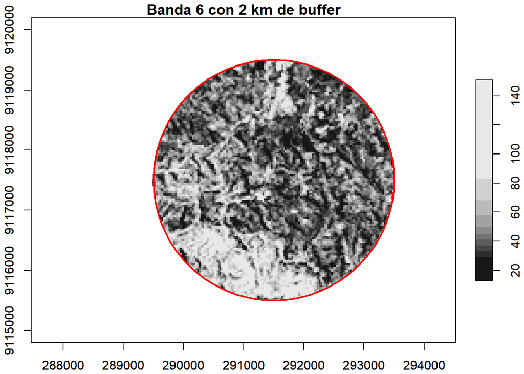

```r
# 1 Creación del círculo y definición del sistema de referencia
circulo = st_sfc(st_buffer(st_point(c(291500, 9117500)), 2000),
                 crs = st_crs(img))
# 2 corte
img_cir <- img[circulo][, , , 6]

# 3 visualización
plot(img_cir,
     axes  = T,
     reset = FALSE,
     main  = "Banda 6 con 2 km de buffer",
     ylim  = c(9115000, 9120000),
     xlim  = c(288000, 294000))

plot(circulo,
     col    = NA,
     border = 'red',
     add    = TRUE,
     lwd    = 2)
```

También podemos usar un polígono, para simplificar usaremos un polígono cuadrado de 3 km.

1. Creacion del poligono de 3 km x 3 km
2. Transformar la geometria en poligono
3. Definir o sistema de referencia, igual al de la imagen a cortar y transformar el objeto tipo sfg (geometria) em sfc (lista de geometria).
4. Visualizar el polígono
5. Cortar la imagen en las 3 bandas visibles, usando el poligono. Las bandas pueden determinarse específicamente también.
6. Visualizar

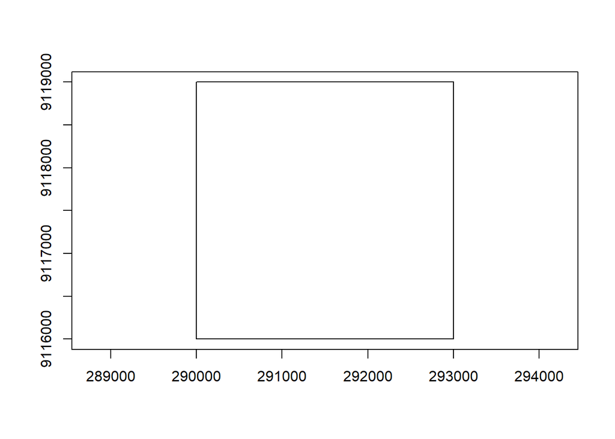

```r
# 1
pt1 = st_point(c(290000, 9119000))
pt2 = st_point(c(293000, 9119000))
pt3 = st_point(c(293000, 9116000))
pt4 = st_point(c(290000, 9116000))
pt5 = st_point(c(290000, 9119000)) # punto de cierre, igual al pt1
# 2
pol <-st_polygon(list(rbind(pt1, pt2, pt3, pt4, pt5)))
# 3
pol <- st_sfc(pol, crs = st_crs(img))
# 4
plot(pol, axes=T)
```

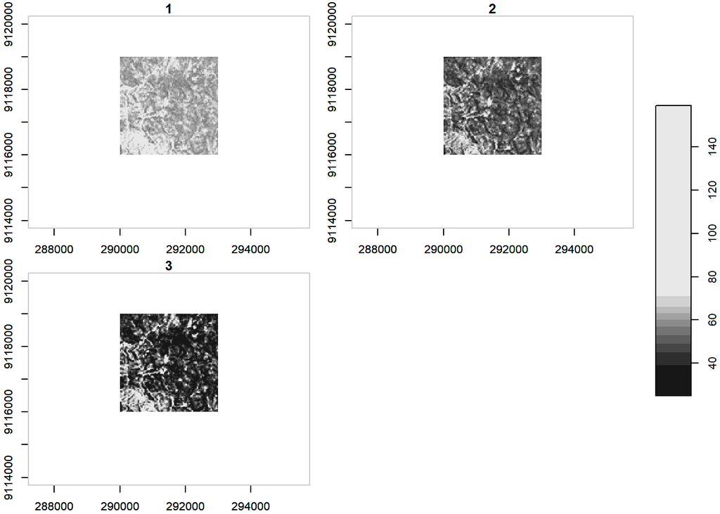

```r
# 5
img_corte2 <- img[pol][, , , 1:3]
# 6
plot( img[pol][, , , 1:3],
      axes = T,
      xlim = c(289000, 294000),
      ylim = c(9114000, 9120000))
```

### Otras herramientas de extracción de datos

Extracción usando la función *st_crop()* de la biblioteca **sf**. Fue colocado en el fragmento de código siguiente dos formas diferentes, usando el polígono ya definido anteriormente o estableciendo los límites del corte en forma explícita con un vector numérico. Esta función solo puede ser usada con formas rectangulares.

```r
p <- st_crop(img[, , , 1:3], pol)
```

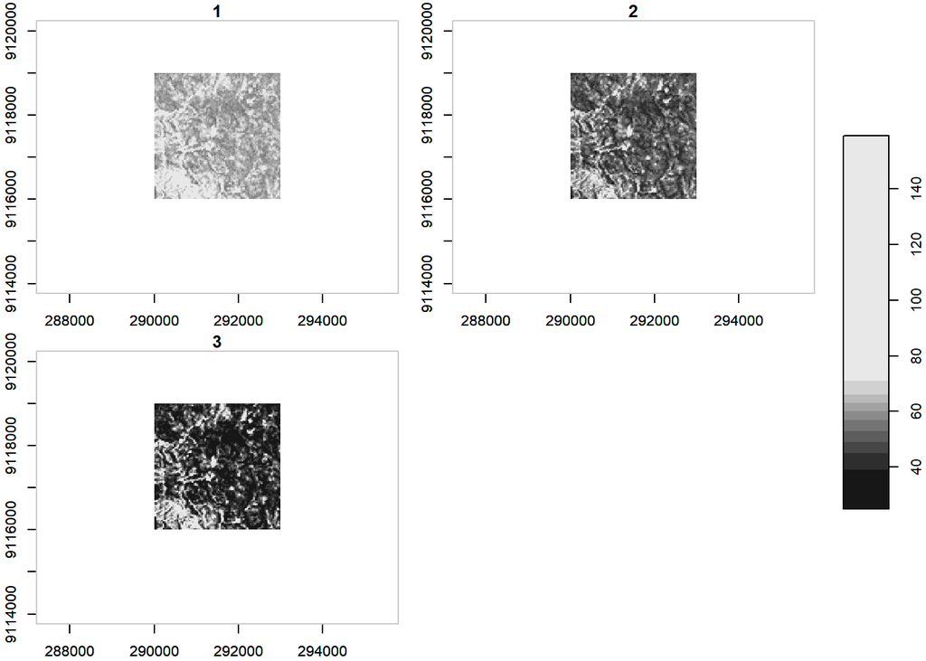

```r
# el polígono también puede ser determinado con xmin, ymin, xmax, ymax de la forma:
# p <- st_crop(img, c(290000, 9116000, 293000, 9119000))
#
plot(p, axes = T,
      xlim = c(289000, 294000),
      ylim = c(9114000, 9120000))
```

La función *cut* corta la imagen, clasificando los valores en categorias, por exemplo, en el fragmento de código que sigue vamos a clasificar cada banda en tres categorias: valores de pixel entre 0 y 50, entre 50 y 100, y finalmente entre 100 y 255. Esta función pode ser útil en caso de querer extraer o eliminar valores determinados del atributo.

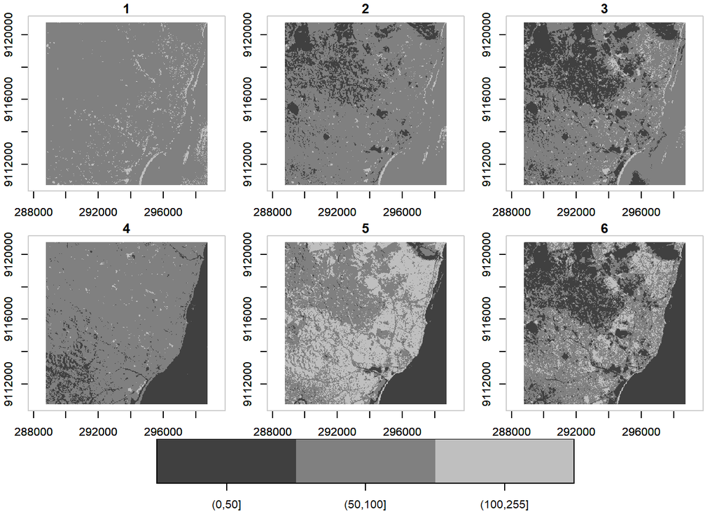

```r
img_corte3 <- cut(img, c(0, 50, 100, 255))

plot(img_corte3, axes =T )
```

Otra función que puede ser útil es *slice()* de la biblioteca *dplyr*, que también permite extraer, por ejemplo, bandas o valores determinados de cada dimensión.

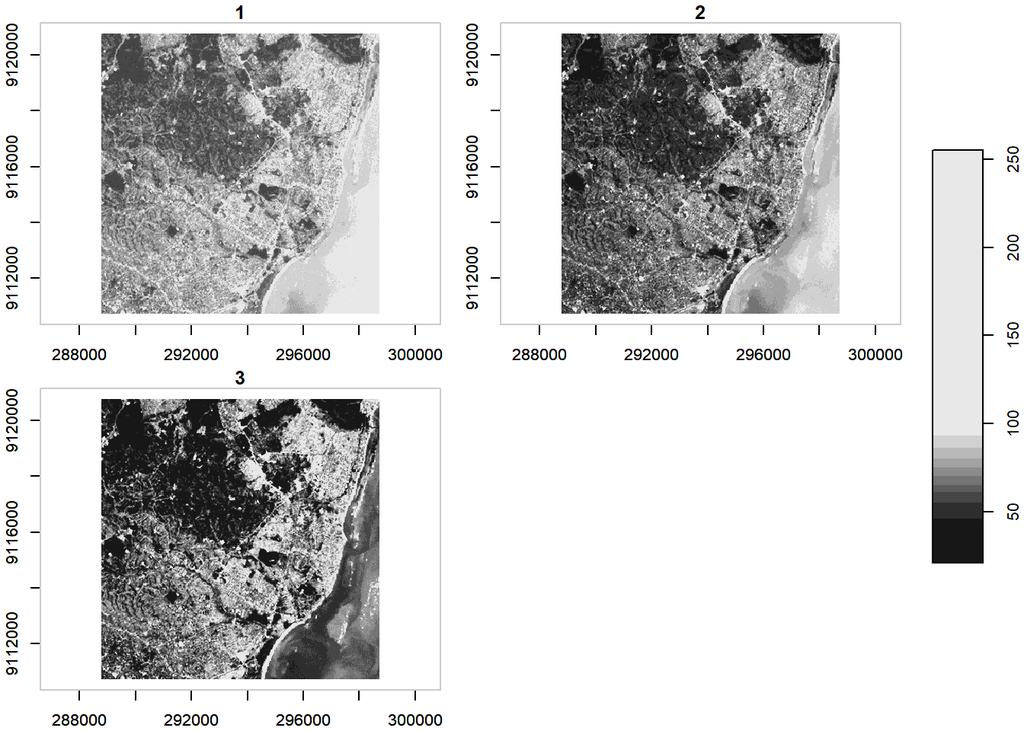

```r
library(dplyr)
img_s1  <-   img %>% slice("band", 1:3)

plot(img_s1, axes = T)
```

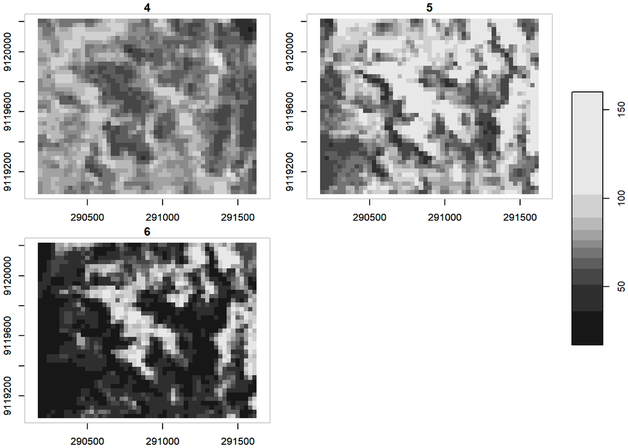

```r
img_s2 <- img        %>%
  slice("x", 50:100) %>%
  slice("y", 20:60)  %>%
  slice("band", 4:6)

plot(img_s2, axes = T)
```